# Overview of Statistical Learning and Modeling – 36-600

Lab 4R: Unsupervised Learning II Due Friday, September 19, 11:59pm

Trishla Nair

This lab will be a relatively short one, given that you are also working through your EDA Project.

To answer the questions below, it again may help you to refer to Sections 10.3 and 10.5 of the ISLR book (the James et al. book listed on the syllabus), as well as previous labs.

## Question 1

Like we did last time, let’s create a fake dataset:

```r
set.seed(505)
(df <- data.frame(x = runif(3), y = runif(3), z = runif(3)))
```

```
##            x          y         z
## 1 0.13110363 0.09073694 0.1741910
## 2 0.50395610 0.02070792 0.1276750
## 3 0.09991132 0.78558310 0.3049695
```

Compute and show the pairwise distance matrix for the *scaled* data. (This is what you would pass into `hclust()`, so there is a good reason for doing this.) You should see a lower-triangular matrix as output, with three values between 1 and 4. Mentally note the smallest value.

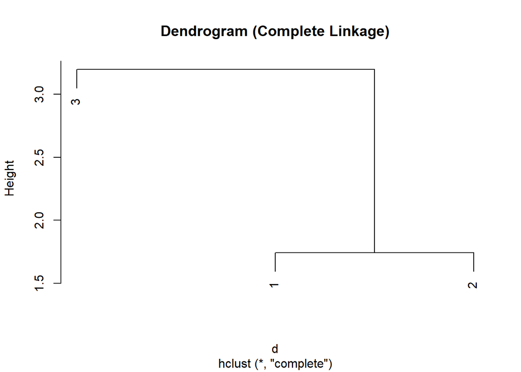

```r
d <- dist(scale(df))
d.mat <- as.matrix(d)
hc.out <- hclust(d)
plot(hc.out, main = "Dendrogram (Complete Linkage)")
```

## Question 2

Now run hierarchical clustering, inputting the distance matrix you created above, using *average linkage*, and plot the resulting dendrogram. What you *should* see is that the height of the first merge is (visually, roughly) the same as that smallest distance value from the last question. You can confirm this by looking at the `height` element of the list output by `hclust`. This makes sense: the smallest dissimilarity between our data points is exactly the smallest observed Euclidean distance between the points.

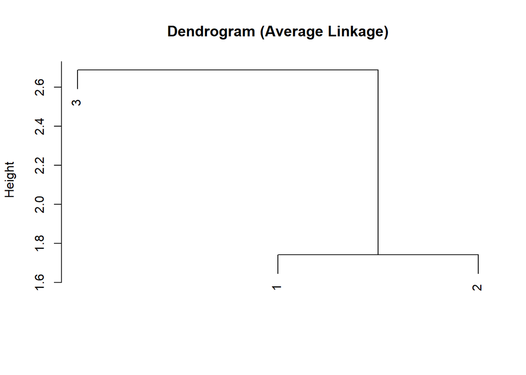

```r
d <- dist(scale(df))
hc.out <- hclust(d, method = "average")

plot(hc.out, main = "Dendrogram (Average Linkage)", xlab = "", sub = "")
```

```r
min_dist <- min(d)
first_merge_height <- hc.out$height[1]
cat("Smallest pairwise distance:", min_dist, "\n")
```

```
## Smallest pairwise distance: 1.741874
```

```r
cat("Height of first merge:", first_merge_height, "\n")
```

```
## Height of first merge: 1.741874
```

## Dataset

Let’s import the same stellar dataset we used in the previous lab.

```r
file.path <- "https://github.com/FSKoerner/F25-36600-data/raw/refs/heads/main/draco_photometry.Rdata"
load(url(file.path))
df <- data.frame(ra, dec, "v" = velocity.los, log.g,
                 "g" = mag.g, "r" = mag.r, "i" = mag.i)
rm(file.path, ra, dec, velocity.los, log.g, temperature,
   mag.u, mag.g, mag.r, mag.i, mag.z, metallicity, signal.noise)
suppressMessages(library(tidyverse))
df %>%
  filter(., ra < 264 & dec > 56 & v > -350 & v < -250) %>%
  mutate(., gr = g-r, ri = r-i) %>%
  select(., -g, -r, -i, -v) -> df.new
```

## Question 3

Use the `hclust()` function to build a hierarchical clustering tree for `df.new`, and use the basic `plot()` function to display the dendrogram. Try both complete and average linkage: which one makes for the best-looking output? (This should **not** be confused with which one gives the best clustering result. *Note*: there is no “right” answer here; best-looking is in the eye of the statistical consultant.) Despite talking up the dendrogram in class, is this output actually useful? Why or why not? If your client asked for a dendrogram, what step might you want to consider taking before providing one? (*Note*: when calling `plot()`, consider passing the argument `labels = FALSE` to remove the row numbers at the base of dendrogram.)

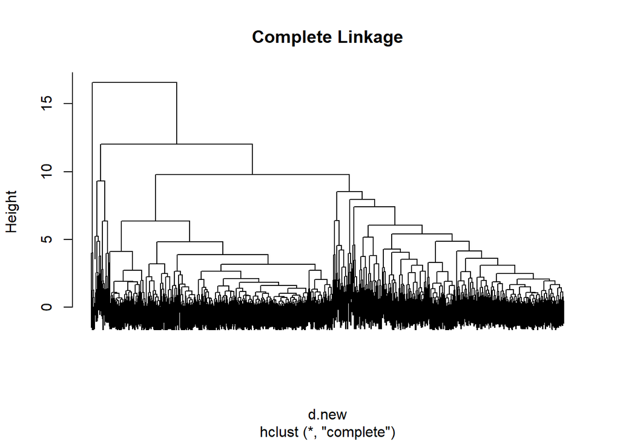

```r
df.new.scaled <- scale(df.new)

# Compute distances
d.new <- dist(df.new.scaled)

# Complete linkage
hc.complete <- hclust(d.new, method = "complete")
plot(hc.complete, labels = FALSE, main = "Complete Linkage")
```

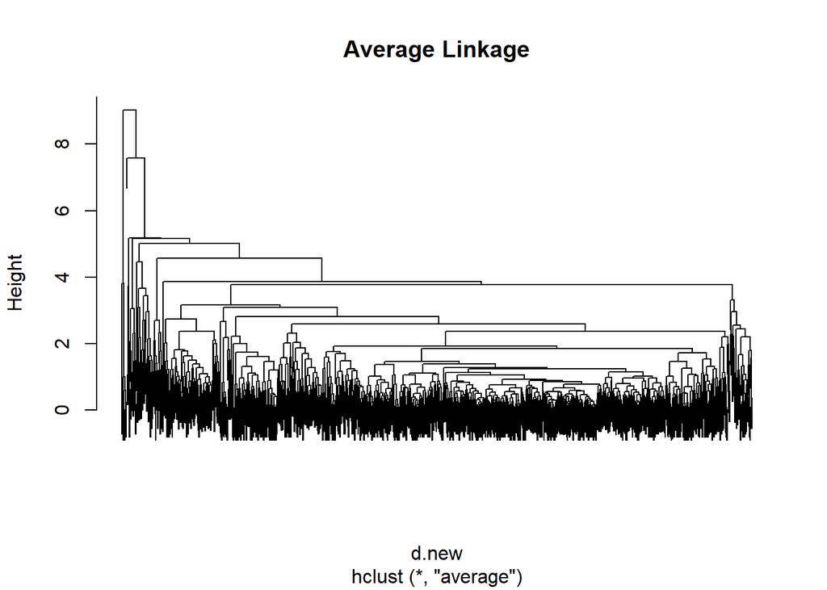

```
While they show the clusters, a denedrogram is more useful when the data size is smaller because it is more cleaner to understand.
```

```r
# Average linkage
hc.average <- hclust(d.new, method = "average")
plot(hc.average, labels = FALSE, main = "Average Linkage")
```

## Question 4

```r
library(GGally)
```

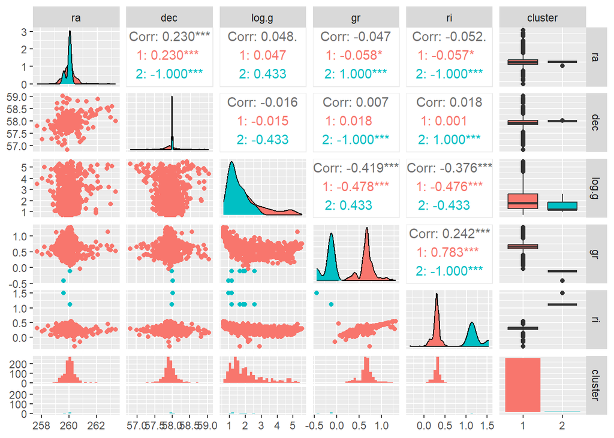

[output not shown]

```r
cluster.hc <- cutree(hc.complete, k = 2)
df.plot <- as.data.frame(df.new)
df.plot$cluster <- factor(cluster.hc)
ggpairs(df.plot, aes(color = cluster))
```

## Question 5

Implement a GMM-based analysis using the `ClusterR` package, analogously to what was done in the notes. Assume *two* clusters. Your final goal is to figure out the proportions of the observations that can be confidently placed in either Cluster 1 or Cluster 2 (i.e., having cluster probabilities >0.95). The placement of the rest of the observations can be considered ambiguous. As a reminder, one of the outputs from `predict_GMM` is `cluster_proba`. Here, that will be a 1218 x 2 matrix, where the probabilities within each row sum to 1. So, determine how many values in the first column of `cluster_proba` are either <0.05 (the datum is to be associated with *Cluster 2* with high probability) or >0.95, then divide by the number of rows in `cluster_proba`. (Note that I found $\approx$ 77.9% of the data can be confidently placed in one of the two clusters.)

(*Note*: you will have to install `ClusterR` and uncomment the line below before completing this question.)

```r
library(ClusterR)
gmm.out <- GMM(df.new, gaussian_comps = 2)
pred    <- predict_GMM(df.new, gmm.out$centroids, gmm.out$covariance_matrices, gmm.out$weights)
gmm.out$centroids
```

```
##         [,1]     [,2]     [,3]      [,4]      [,5]
## [1,] 260.135 57.94114 3.566123 0.5465523 0.2363298
## [2,] 260.027 57.93575 1.598547 0.6884864 0.3264657
```

```r
names(pred)
```

```
## [1] "log_likelihood" "cluster_proba"  "cluster_labels"
```